# Fric et al. Re-analysis Code

Vaughn Shirey & Elise Larsen

Current version 11/18/2020; initiated 3/9/2020

Begin Analysis

Set up workspace Load necessary packages If phest is not already installed, remove comment from install line

```r
# load libraries
library(tidyverse)
```

```r
library(ggplot2)
library(ggExtra)
library(gridExtra)
#library(devtools); install_github("willpearse/phest")
library(phest)
library(readxl)

#start fresh
rm(list=ls())
```

#### Data Import and Formatting

data.csv file was downloaded from https://doi.org/10.6084/m9.figshare.9946934 (https://figshare.com/articles/Phenology_responses_of_temperate_butterflies_-_Supplementary_data/9946934)

This cvs file contains the occurrence data used in Fric et al. (2020), which they downloaded from gbif. The file includes separate data tables for each dataset, which have been concatenated into one file. These data tables have the same fields but are not formatted as a single data table; individual datasets were all written into one data file, including headers and row indices in each dataset. This first set of code reformats the data & writes formatted data files.

```r
all.data <- readLines("fric_supplements/data.csv")

#identify header rows
all.header.rows<-grep("decimalLongitude", all.data)

#check headers for consistency
uniqueheaders<-unique(all.data[all.header.rows])

# 2 versions!
# Get row numbers for "header 1"
header.rows1<-grep(uniqueheaders[1], all.data)
#Get row numbers for "header 2" - all header rows that aren't "header 1"
header.rows2<-setdiff(all.header.rows, header.rows1)

#Create row index: 0 is a header row, 1 is format 1 data, 2 is format 2 data
j<-rep(0,length(all.data))
for (i in all.header.rows) {
  #set index to the next header. if it's not the last header, Otherwise set to end of datafile + 1
  if(i<max(all.header.rows)) {
    next_index<-min(all.header.rows[all.header.rows>i])
  }else { next_index<-length(all.data)+1 }

  #for data between header rows, set row index
  j[(i+1):(next_index-1)]<-ifelse(i%in%header.rows1,1,2)
}

#need to add a row index to the header text for new data files
newheader1<-paste('"row.index\",' ,uniqueheaders[1], sep="")
newheader2<-paste('"row.index\",' ,uniqueheaders[2], sep="")

#write data file
formatteddatafile1<-file("data/fric_data_header_1.txt")
writeLines(c(newheader1,all.data[which(j==1)]), formatteddatafile1)
close(formatteddatafile1)

formatteddatafile2<-file("data/fric_data_header_2.txt")
writeLines(c(newheader2,all.data[which(j==2)]), formatteddatafile2)
close(formatteddatafile2)
rm(list=ls())

#read back in the formatted data
data1<-read_csv("data/fric_data_header_1.txt")
data2<-read_csv("data/fric_data_header_2.txt")
paste( nrow(data1), "records in format 1;", nrow(data2), "records in format 2")
```

```
## [1] "49243 records in format 1; 233201 records in format 2"
```

```r
occur1<-rbind(data1,data2)
rm(data1,data2)

##Fric et al includes different species names in results tables than found in data table. Manual corrections to match results tables:
name_changes<-read_csv("data/name_changes.csv")
table(occur1$name[which(occur1$name %in% name_changes$data_name)])
```

```
##
##    Callophrys polios    Fabriciana adippe       Lethe eurydice
##                   99                 5924                   72
##       Lycaeides idas Phyciodes campestris     Phyciodes tharos
##                   19                   42                  136
##   Thymelicus lineola
##                11179
```

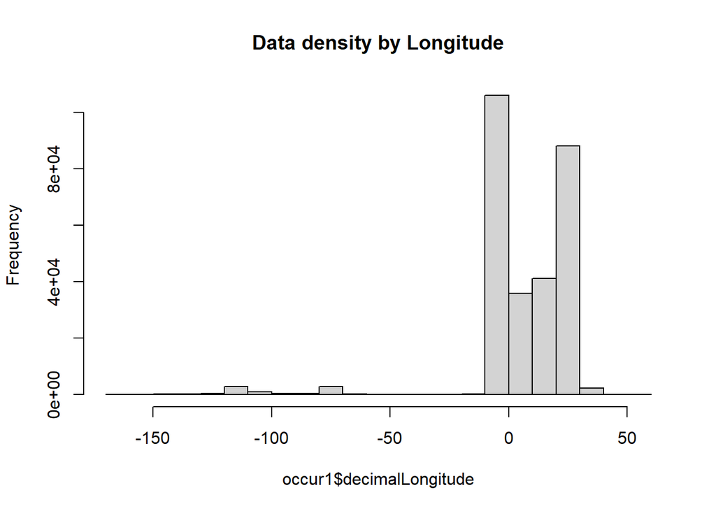

```r
for(namei in 1:nrow(name_changes)) {
  occur1$name[occur1$name==name_changes$data_name[namei]]<-name_changes$results_name[namei]
}

rm(name_changes)
## visualize data density by longitude
hist(occur1$decimalLongitude, main="Data density by Longitude")
```

```r
#ID records by region. Everything East of -40 is Europe, the rest is N. America
occur1<-occur1 %>%
  #Assign region by longitude.
  mutate(region=ifelse(decimalLongitude>=(-40),"Europe","N. America"))

#Fric et al removed all 1st of month observations and removed one species due to late season nests
occur<-filter(occur1, day!=1, name!="Euphydryas aurinia")

summary(occur)
```

```
##    row.index         name           decimalLongitude   decimalLatitude
##  Min.   :    1   Length:275457      Min.   :-162.559   Min.   : 5.787
##  1st Qu.: 2340   Class :character   1st Qu.:  -2.676   1st Qu.:52.823
##  Median : 7074   Mode  :character   Median :   9.564   Median :55.775
##  Mean   :15039                      Mean   :   6.716   Mean   :56.354
##  3rd Qu.:20814                      3rd Qu.:  23.763   3rd Qu.:60.677
##  Max.   :85273                      Max.   :  59.333   Max.   :71.216
##
##       year          month        country               day
##  Min.   :1616   Min.   : 1.0   Length:275457      Min.   : 2.00
##  1st Qu.:1992   1st Qu.: 6.0   Class :character   1st Qu.: 9.00
##  Median :2002   Median : 7.0   Mode  :character   Median :16.00
##  Mean   :1996   Mean   : 6.5                      Mean   :16.19
##  3rd Qu.:2009   3rd Qu.: 7.0                      3rd Qu.:24.00
##  Max.   :2015   Max.   :12.0                      Max.   :31.00
##  NA's   :57
##     SuccDay          rndLat           alt              region
##  Min.   :  2.0   Min.   : 6.00   Min.   :-2666.74   Length:275457
##  1st Qu.:164.0   1st Qu.:53.00   1st Qu.:   23.25   Class :character
##  Median :186.0   Median :56.00   Median :   64.24   Mode  :character
##  Mean   :181.2   Mean   :56.29   Mean   :  113.64
##  3rd Qu.:201.0   3rd Qu.:61.00   3rd Qu.:  110.77
##  Max.   :361.0   Max.   :71.00   Max.   : 4305.17
##
```

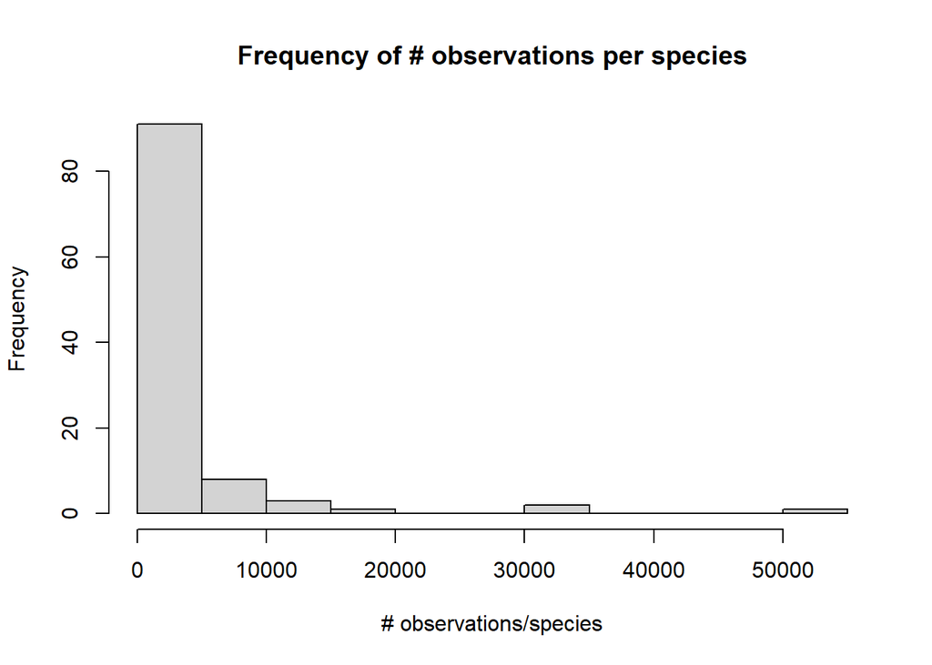

```r
tempoccurplot<-occur %>% group_by(name) %>% tally()
hist(tempoccurplot$n,xlab="# observations/species", main="Frequency of # observations per species")
```

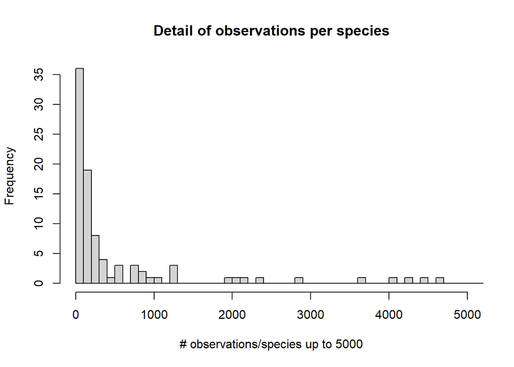

```r
hist(tempoccurplot$n[tempoccurplot$n<5000],xlab="# observations/species up to 5000", xlim=c(0,5000), main="Detail of observations per species", breaks=c(0:5000*100))
```

```r
rm(tempoccurplot)
```

#### Data exploration:

```r
#Tally the number of observations per dataset & calculate how each dataset spans latitude, year, altitude
spans.summary<-occur %>%
  group_by(name, region) %>%
  add_count(name="fric_n") %>% ## n. records
  group_by(name, region, fric_n) %>%
  summarize(lat_span=(max(rndLat, na.rm=T)-min(rndLat, na.rm=T)),
         year_span=(max(year, na.rm=T)-min(year, na.rm=T)),
         alt_span=round((max(alt, na.rm=T)-min(alt, na.rm=T)),0))
```

```r
#calculate # latitudes, onsets, terminations, flight curves = 0
endpt.summary<-occur %>%
  group_by(name, region, rndLat) %>%
  # count no. records by latitudinal band
  add_count(name="n_recs") %>%
  #filter to onset & offset dates and label onset dates and offset dates
  filter(SuccDay==min(SuccDay) | SuccDay==max(SuccDay)) %>%
  mutate(onset=ifelse(SuccDay==min(SuccDay),1,0),    term=ifelse(SuccDay==max(SuccDay),1,0)) %>%
  group_by(name, region) %>%
  #create summary statistics by species & region
  summarize(n_lat=length(unique(rndLat)), n_onset=sum(onset), n_term=sum(term), n_flightcurve0s=sum(n_recs==1) )
#combine summary tables
fric.data.summary<-merge(spans.summary, endpt.summary, by=intersect(names(spans.summary), names(endpt.summary)))
rm(spans.summary)
summary(fric.data.summary)
```

```
##      name              region              fric_n            lat_span
##  Length:112         Length:112         Min.   :    4.00   Min.   :10.00
##  Class :character   Class :character   1st Qu.:   76.25   1st Qu.:23.00
##  Mode  :character   Mode  :character   Median :  186.50   Median :27.00
##                                        Mean   : 2459.44   Mean   :26.12
##                                        3rd Qu.: 1080.75   3rd Qu.:30.00
##                                        Max.   :51819.00   Max.   :64.00
##    year_span        alt_span        n_lat          n_onset          n_term
##  Min.   :  4.0   Min.   : 530   Min.   : 2.00   Min.   : 2.00   Min.   : 2.00
##  1st Qu.:101.8   1st Qu.:2059   1st Qu.:12.00   1st Qu.:14.75   1st Qu.:13.00
##  Median :116.5   Median :2658   Median :18.00   Median :19.00   Median :20.00
##  Mean   :125.2   Mean   :2691   Mean   :18.74   Mean   :20.22   Mean   :19.96
##  3rd Qu.:138.2   3rd Qu.:3398   3rd Qu.:25.00   3rd Qu.:27.00   3rd Qu.:26.00
##  Max.   :399.0   Max.   :5163   Max.   :33.00   Max.   :39.00   Max.   :35.00
##  n_flightcurve0s
##  Min.   : 0.000
##  1st Qu.: 2.000
##  Median : 3.000
##  Mean   : 3.375
##  3rd Qu.: 5.000
##  Max.   :10.000
```

#### Explore data by altitude & latitude

##### Create Figure 1: Occurrences by altitude & latitude

This figure uses the 4 species presented in Fric et al. Figure 1, and visualized the spatiotemporal bias and prevalence of flight periods with a duration of 0 days.

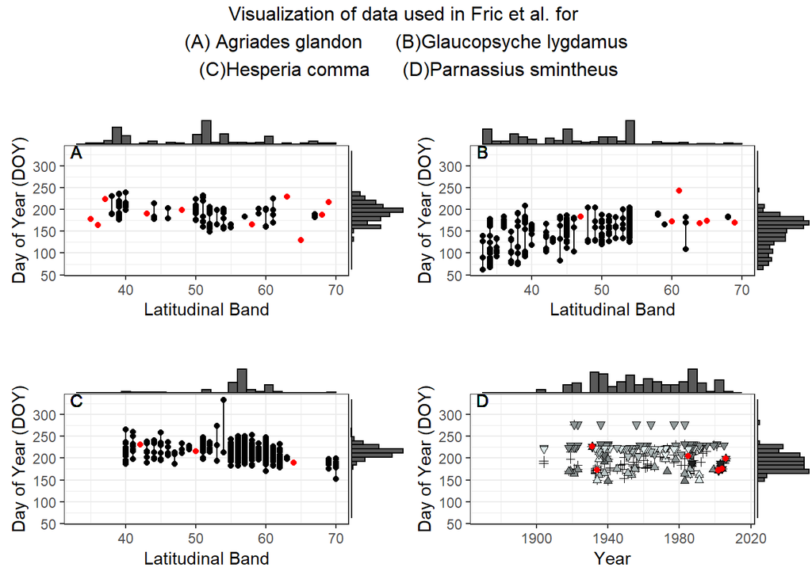

```r
#species list
fig1sp<-c("Agriades glandon","Glaucopsyche lygdamus","Hesperia comma","Parnassius smintheus")

#Filter data to these species
fig1data<-occur %>%
  filter(name %in% fig1sp)

#Get onset & termination dates (SuccDay)
f1.pheno.data<-fig1data %>%
  group_by(name, region, rndLat) %>%
  mutate(onset=min(SuccDay), term=max(SuccDay), fp=term-onset, singles=ifelse(length(SuccDay)==1,1,0))

f1.pheno.data2<-f1.pheno.data %>%
  filter(SuccDay==onset | SuccDay==term)


#A list to store plot panels
tempplot<-list()
fig1panels<-list()
#The order the panels will be displayed in Figure 1
#4 is skipped because it is H. comma in North America, not shown in Fig 1
ds1<-c(1,3,2,4)  #  for marrangeGrob - by columns
tags<-c("A","B","C","D")

#Create Panels
for(i in 1:2) {
  #paneltitle<-paste(fig1sp[i],"N. America")
  tempplot[[i]] <- ggplot(filter(f1.pheno.data, name==fig1sp[i], region=="N. America"), aes(x=rndLat, y=SuccDay, color=as.factor(singles))) +
    theme_bw() +
    theme(legend.position="none", plot.margin = margin(1,1,1,1, "in")) +
    geom_segment(data=filter(f1.pheno.data2, name==fig1sp[i], region=="N. America"), aes(x=rndLat, y=onset, xend=rndLat, yend=term)) +
    geom_point(aes(color=as.factor(singles))) +
    scale_color_manual(values=c("black","red")) +
    xlim(min(f1.pheno.data$rndLat),max(f1.pheno.data$rndLat)) + ylim(min(f1.pheno.data$SuccDay),max(f1.pheno.data$SuccDay)) +
    labs(x="Latitudinal Band", y="Day of Year (DOY)", title="") + geom_text(x=min(f1.pheno.data$rndLat), y=max(f1.pheno.data$SuccDay), label=tags[i])

  # with marginal histograms
  fig1panels[[i]] <- ggMarginal(tempplot[[i]], type="histogram")
  }


i<-3 #H. comma panel in Fric et al. is from Europe
#paneltitle<-paste(fig1sp[i],"Europe")
  tempplot[[i]] <- ggplot(filter(f1.pheno.data, name==fig1sp[i], region=="Europe"), aes(x=rndLat, y=SuccDay, color=as.factor(singles))) +
    theme_bw() +
    theme(legend.position="none", plot.margin = margin(1,1,1,1, "in")) +
    geom_segment(data=filter(f1.pheno.data2, name==fig1sp[i], region=="Europe"), aes(x=rndLat, y=onset, xend=rndLat, yend=term)) +
    geom_point(aes(color=as.factor(singles))) +
    scale_color_manual(values=c("black","red")) +
    xlim(min(f1.pheno.data$rndLat),max(f1.pheno.data$rndLat)) + ylim(min(f1.pheno.data$SuccDay),max(f1.pheno.data$SuccDay)) +
    labs(x="Latitudinal Band", y="Day of Year (DOY)", title="") + geom_text(x=min(f1.pheno.data$rndLat), y=max(f1.pheno.data$SuccDay), label=tags[i])

  # with marginal histogram
  fig1panels[[i]] <- ggMarginal(tempplot[[i]], type="histogram")

##### Figure 1d  2020-07-29 update uses YEAR and DAY to mirror Fric et al.
i<-4
#paneltitle<-paste(fig1sp[i],"N. America")
tempplot[[i]]<- ggplot(filter(f1.pheno.data, name==fig1sp[i], region=="N. America"), aes(x=year, y=SuccDay, fill=decimalLatitude)) +
  geom_point(shape=3) +
  theme_bw() +
  theme(legend.position="none", plot.margin = margin(1,1,1,1, "in")) +
  geom_point(data=filter(f1.pheno.data2, name==fig1sp[i], region=="N. America"), aes(x=year, y=onset, fill=decimalLatitude), shape=24) +
  geom_point(data=filter(f1.pheno.data, name==fig1sp[i], region=="N. America"), aes(x=year, y=term, fill=decimalLatitude), shape=25) +
  scale_fill_gradient(low="azure1", high="black") +
  geom_point(data=filter(f1.pheno.data2, name==fig1sp[i], region=="N. America", singles==1), aes(x=year, y=SuccDay), color="red", shape=16) +
  xlim(min(f1.pheno.data$year),max(f1.pheno.data$year)) + ylim(min(f1.pheno.data$SuccDay),max(f1.pheno.data$SuccDay)) +
  labs(x="Year", y="Day of Year (DOY)", title="") + geom_text(x=min(f1.pheno.data$year), y=max(f1.pheno.data$SuccDay), label=tags[i])


# with marginal histogram
fig1panels[[i]]  <- ggMarginal(tempplot[[4]], type="histogram")

grid.arrange(grobs=fig1panels[c(1:4)], nrow=2, ncol=2, top="Visualization of data used in Fric et al. for \n (A) Agriades glandon      (B)Glaucopsyche lygdamus \n (C)Hesperia comma      (D)Parnassius smintheus")
```

```r
#Used to create figure 1 pdf
#pdf_filename<-("Larsen&Shirey2020_FinalFig1.pdf")
#ggsave(pdf_filename, arrangeGrob(grobs=fig1panels[ds1], nrow=2, ncol=2), width=6, height=6, units="in", scale=1,dpi=600)

#rm(f1.pheno.data,f1.pheno.data2, fig1data,fig1panels,fig1sp, ds1,tempplot, tags, i)
```

#### Data curation:

Data have now been formatted, identified by region, and summarized. The following code chunk applies the filters used in the Larsen & Shirey reanalysis and calculates summary data density statistics for supplemental table 1.

Unlike Fric et al., we included first day of the month records Filters: 1 - altitude in [0m,500m] 2 - 10 or more records when data is grouped by species, region, year, and latitudinal band

```r
#Summarize data availability for Larsen & Shirey re-analysis
#Now, filter data for altitude & for cases with 10 or more records by species-region-year-latitude
new.data.summary<-occur1 %>%
  filter(between(alt,0,500), name!="Euphydryas aurinia") %>%
  # calculate data availability by species, region, latitude & year
  group_by(name, region, rndLat, year) %>%
  add_count(name="group_n") %>% ## n. observations per group
  filter(group_n>=10) %>% ### filter by 10 or more observations in group
  # calculate reanalysis statistics by species & region
  group_by(name, region) %>%
  add_count(name="curated_n_obs") %>%
  group_by(name, region, curated_n_obs) %>%
  #calculate summary statistics applying data filters
  summarize(curated_n_lat=length(unique(rndLat)),  curated_n_fcurve=length(unique(paste(rndLat,year))),
            curated_lat_span=(max(rndLat, na.rm=T)-min(rndLat, na.rm=T)),
            curated_year_span=(max(year, na.rm=T)-min(year, na.rm=T)),
            curated_alt_span=round((max(alt, na.rm=T)-min(alt, na.rm=T)),0))
#combine summary tables
supptable1<-merge(fric.data.summary, new.data.summary, by=intersect(names(fric.data.summary), names(new.data.summary)), all.x=T)
head(supptable1)
```

```
##                     name     region fric_n lat_span year_span alt_span n_lat
## 1       Agriades glandon N. America    110       34       103     4042    26
## 2      Agriades optilete     Europe     86       25       111     2940    15
## 3    Amblyscirtes vialis N. America     88       29       133     2775    19
## 4 Anthocharis cardamines     Europe  31849       32       168     2595    33
## 5       Anthocharis sara N. America    218       28       111     4417    21
## 6  Aphantopus hyperantus     Europe  30598       25       399     2102    26
##   n_onset n_term n_flightcurve0s curated_n_obs curated_n_lat curated_n_fcurve
## 1      27     27              10            NA            NA               NA
## 2      15     15               5            NA            NA               NA
## 3      19     19               7            NA            NA               NA
## 4      39     35               2         29152            17              393
## 5      22     22               6            NA            NA               NA
## 6      27     28               1         27887            15              330
##   curated_lat_span curated_year_span curated_alt_span
## 1               NA                NA               NA
## 2               NA                NA               NA
## 3               NA                NA               NA
## 4               16                80              499
## 5               NA                NA               NA
## 6               14                79              488
```

```r
summary(supptable1)
```

```
##      name              region              fric_n            lat_span
##  Length:112         Length:112         Min.   :    4.00   Min.   :10.00
##  Class :character   Class :character   1st Qu.:   76.25   1st Qu.:23.00
##  Mode  :character   Mode  :character   Median :  186.50   Median :27.00
##                                        Mean   : 2459.44   Mean   :26.12
##                                        3rd Qu.: 1080.75   3rd Qu.:30.00
##                                        Max.   :51819.00   Max.   :64.00
##
##    year_span        alt_span        n_lat          n_onset          n_term
##  Min.   :  4.0   Min.   : 530   Min.   : 2.00   Min.   : 2.00   Min.   : 2.00
##  1st Qu.:101.8   1st Qu.:2059   1st Qu.:12.00   1st Qu.:14.75   1st Qu.:13.00
##  Median :116.5   Median :2658   Median :18.00   Median :19.00   Median :20.00
##  Mean   :125.2   Mean   :2691   Mean   :18.74   Mean   :20.22   Mean   :19.96
##  3rd Qu.:138.2   3rd Qu.:3398   3rd Qu.:25.00   3rd Qu.:27.00   3rd Qu.:26.00
##  Max.   :399.0   Max.   :5163   Max.   :33.00   Max.   :39.00   Max.   :35.00
##
##  n_flightcurve0s  curated_n_obs     curated_n_lat    curated_n_fcurve
##  Min.   : 0.000   Min.   :   10.0   Min.   : 1.000   Min.   :  1.00
##  1st Qu.: 2.000   1st Qu.:   36.5   1st Qu.: 1.500   1st Qu.:  2.50
##  Median : 3.000   Median :  361.0   Median : 3.000   Median : 23.00
##  Mean   : 3.375   Mean   : 3861.0   Mean   : 6.073   Mean   : 77.98
##  3rd Qu.: 5.000   3rd Qu.: 3928.0   3rd Qu.:10.000   3rd Qu.:124.50
##  Max.   :10.000   Max.   :47679.0   Max.   :17.000   Max.   :393.00
##                   NA's   :57        NA's   :57       NA's   :57
##  curated_lat_span curated_year_span curated_alt_span
##  Min.   : 0.000   Min.   :  0.00    Min.   :  0.0
##  1st Qu.: 0.500   1st Qu.:  8.00    1st Qu.:214.0
##  Median : 5.000   Median : 35.00    Median :379.0
##  Mean   : 6.618   Mean   : 43.42    Mean   :324.7
##  3rd Qu.:12.000   3rd Qu.: 74.00    3rd Qu.:467.5
##  Max.   :18.000   Max.   :123.00    Max.   :499.0
##  NA's   :57       NA's   :57        NA's   :57
```

```r
#output summary table to csv file
#write_csv(supptable1, "Larsen&Shirey_stats_supp_table1.csv")
rm(fric.data.summary, new.data.summary, endpt.summary)
```

#### Curate data for reanalysis

This chunk of code filters data for reanalysis and visualizes some differences

```r
#FILTER DATA BY VOLTINISM

#get species list without evidence of multiple generations
voltindata<-read_csv("data/voltinism.csv")
```

```
## Warning: Missing column names filled in: 'X9' [9], 'X10' [10], 'X11' [11],
## 'X12' [12]
```

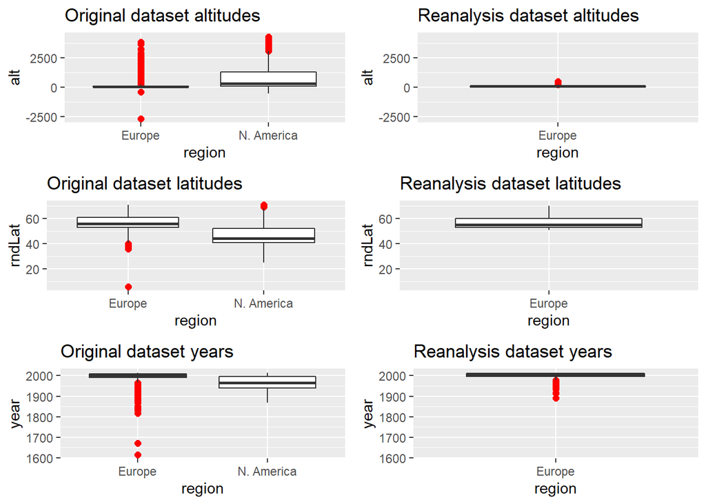

```r
voltindata<-voltindata %>% select(name=name_resultsfile,region,Voltinism)
multi<-c("Bivoltine", "Multivoltine","Sometimes bivoltine","Possible bivoltinism in some subsp.","Unconfirmed reports of second brood")
univoltine<-filter(voltindata, !Voltinism %in% multi)
rm(voltindata, multi)

#filter occurrence dataset to these species
reanalysis.data<-merge(occur1, univoltine, by=intersect(names(occur1),names(univoltine)))

#filter data by altitude and data density
reanalysis.data<-reanalysis.data %>%
  filter(between(alt,0,500), month %in% c(3:11)) %>%
  # calculate data availability by species, region, latitude & year
  group_by(name, region, rndLat, year) %>%
  add_count(name="group_n") %>% ## n. observations per group
  filter(group_n>=10) %>%
  group_by(name, region) %>%
  mutate(nlat=length(unique(rndLat))) %>%
  filter(nlat>=3)

#visualize some differences
plotcompar<-list()
plotcompar[[1]]<-ggplot(data=occur, aes(x=region, y=alt) ) +
  geom_boxplot(outlier.colour="red", outlier.shape=16, outlier.size=2, notch=FALSE) + ggtitle(label="Original dataset altitudes")

plotcompar[[2]]<-ggplot(data=reanalysis.data, aes(x=region, y=alt) ) +
  geom_boxplot(outlier.colour="red", outlier.shape=16, outlier.size=2, notch=FALSE) + ggtitle(label="Reanalysis dataset altitudes") + ylim(min(occur$alt),max(occur$alt))

plotcompar[[3]]<-ggplot(data=occur, aes(x=region, y=rndLat) ) +
  geom_boxplot(outlier.colour="red", outlier.shape=16, outlier.size=2, notch=FALSE) + ggtitle(label="Original dataset latitudes")

plotcompar[[4]]<-ggplot(data=reanalysis.data, aes(x=region, y=rndLat) ) +
  geom_boxplot(outlier.colour="red", outlier.shape=16, outlier.size=2, notch=FALSE) + ggtitle(label="Reanalysis dataset latitudes") + ylim(min(occur$rndLat), max(occur$rndLat))

plotcompar[[5]]<-ggplot(data=filter(occur, !is.na(year)), aes(x=region, y=year) ) +
  geom_boxplot(outlier.colour="red", outlier.shape=16, outlier.size=2, notch=FALSE) + ggtitle(label="Original dataset years")

plotcompar[[6]]<-ggplot(data=reanalysis.data, aes(x=region, y=year) ) +
  geom_boxplot(outlier.colour="red", outlier.shape=16, outlier.size=2, notch=FALSE) + ggtitle(label="Reanalysis dataset years") + ylim(min(occur$year, na.rm=T), max(occur$year, na.rm=T))

grid.arrange(grobs=plotcompar[c(1:6)], nrow=3)
```

####Estimate phenometrics using phest This chunk of code estimates onset and offset phenometrics by species-region-year-latitudinal_band using curated data. We use the phest package to estimate onset and offset of the flight perios based on occurrence data, when at least 10 observations exist for a species-region-year-latitudinal_band unit. Please note that this chunk does take a few minutes to run. Also, warnings are automatically generated by “phest” when a correction is applied to the phenometric estimate. Additionally, “phest” throws a warning for CI estimation. We have explored this warning and don’t believe that it is a problem; therefore we have suppressed the warning messages here.

```r
rm(plotcompar)

#For each species & region, calculate phenometrics
datasets<-reanalysis.data %>% group_by(name, region) %>% tally()
pheno.est<-data.frame(name=character(0),region=character(0),year=integer(0),rndLat=integer(0),onset.est=numeric(0),onset.low=numeric(0),onset.high=numeric(0),offset.est=numeric(0),offset.low=numeric(0),offset.high=numeric(0))

for(rowi in 1:nrow(datasets)){ # for each unique dataset
  namei<-datasets$name[rowi]
  regi<-datasets$region[rowi]
  index <- 1 # create/reset an indexer
  pheno.estimates <- list() # create/refresh a blank list per group
  rowi.data<-filter(reanalysis.data, name==namei, region==regi)
  for(yr in unique(rowi.data$year)){ # and each unique year
    for(lat in unique(rowi.data$rndLat)){ # and each unique latitude
      temp <- filter(rowi.data, rndLat==lat, year==yr) # filter the occurrence data for each group

      if(nrow(temp) > 9){ # if there are at least 10 occurrences, then...
        estimates <- c(namei, regi, yr, lat, nrow(temp),
                       suppressWarnings(weib.limit(temp$SuccDay, upper=FALSE, alpha=0.05)),
                       suppressWarnings(weib.limit(temp$SuccDay, upper=TRUE, alpha=0.05))) # calculate estimates for the group: onset, offset
        pheno.estimates[[index]] <- estimates # shuttle those into a list
        index <- index+1
      } #end if enough occurrences
    } #end lat
  } #end yr
  df <- data.frame(matrix(unlist(pheno.estimates), nrow=length(pheno.estimates), byrow=TRUE),stringsAsFactors=FALSE)
  names(df)<-c("name","region","year","rndLat","n","onset.est","onset.low","onset.high","offset.est","offset.low","offset.high")
  pheno.est<-rbind(pheno.est, df)
}
for(coli in 3:11) {
  pheno.est[,coli]<-as.numeric(pheno.est[,coli])
}

#Format & store data
pheno.data<-pheno.est %>%
  mutate(unit=paste(name, rndLat, year,sep="-")) %>%
  select(unit,onset.est,offset.est,name,region,rndLat,year,n) %>%
  mutate(onset=round(onset.est,0),term=round(offset.est,0))
pheno.data<-na.omit(pheno.data)
#Weibull estimator doesn't bound so
#We bounded all onset & termination metrics y [60,330]
pheno.data$onset[pheno.data$onset<60]<-60
pheno.data$term[pheno.data$term>330]<-330


#save(pheno.data, file="data/phenometrics.RData")
```

#### Statistical models for phenometrics

This chunk of code uses estimated onset and offset phenometrics in linear models to examine phenological patterns.

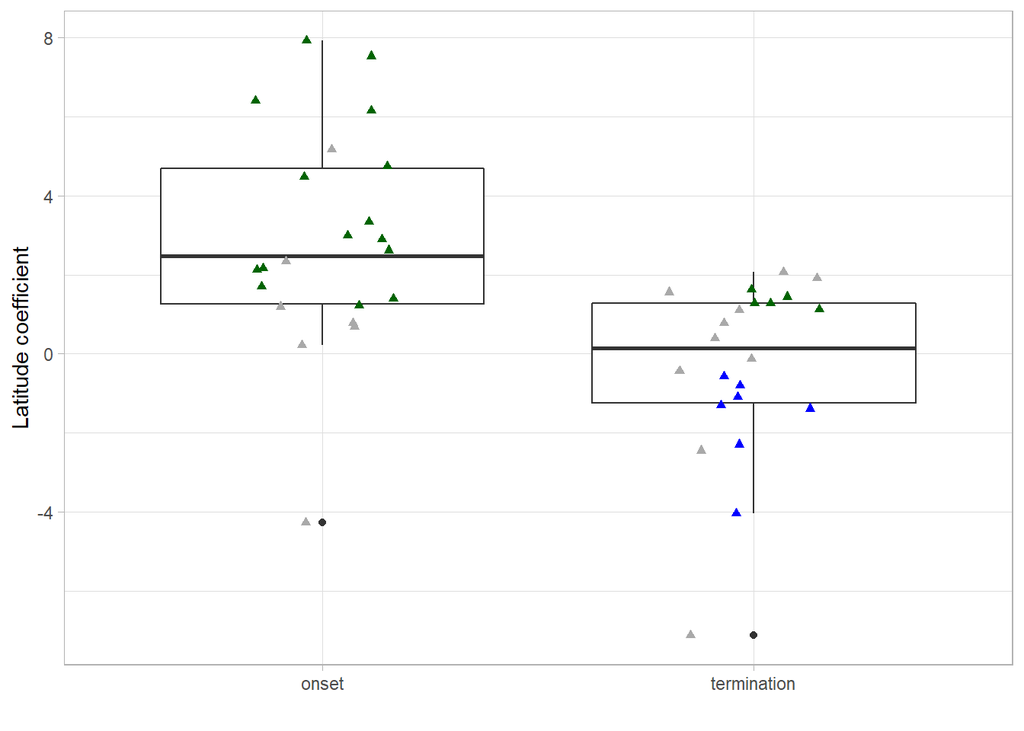

```r
load("data/phenometrics.RData")

datasets<-pheno.data %>%
  group_by(name, region) %>%
  tally()
pheno.data<-na.omit(pheno.data)
#Loop through datasets, run model for phenology by species & region, and store LM parameters
onsetpheno<-list()
termpheno<-list()
onset1<-NULL
term1<-NULL
axes<-NULL

for(rowi in 1:nrow(datasets)) {
  pheno.rowi<-pheno.data %>%
    filter(name==datasets$name[rowi], region==datasets$region[rowi])
#estimate model params for onset
  onset.lm<-summary(lm(onset~rndLat+year, data=pheno.rowi))$coefficients #estimate model params for termination
  term.lm<-summary(lm(term~rndLat+year, data=pheno.rowi))$coefficients
#store
  onsetpheno[[ rowi]]<-onset.lm
  termpheno[[ rowi]]<-term.lm

    #onset
  temponset<-matrix(unlist(onset.lm[c(2:3),]), ncol=4, byrow=F)
  onset1<-rbind(onset1, temponset)
  axes<-c(axes,row.names(onset.lm)[c(2:3)])
#termination
  tempterm<-matrix(unlist(term.lm[c(2:3),]), ncol=4, byrow=F)
  term1<-rbind(term1, tempterm)
  rm(pheno.rowi,onset.lm,term.lm,temponset,tempterm)
  }

#Create results dataframes: onset
onset1<-as.data.frame(onset1)
colnames(onset1)<-c("param.est","param.se","param.t","param.p")
onset1$param<-axes
onset1$metric<-"onset"
onset1$name<-rep(datasets$name, each=2)
onset1$region<-rep(datasets$region, each=2)
onset1$n<-rep(datasets$n, each=2)

#Create results dataframes: termination
term1<-as.data.frame(term1)
colnames(term1)<-c("param.est","param.se","param.t","param.p")
term1$param<-axes
term1$metric<-"termination"
term1$name<-rep(datasets$name, each=2)
term1$region<-rep(datasets$region, each=2)
term1$n<-rep(datasets$n, each=2)


result<-as.data.frame(rbind(onset1, term1))
result<-result %>%
  mutate(response=ifelse(param.p<0.05,ifelse(param.est>0,1,-1),0))

#Plot coefficients colored by response sign
coef.plot1<-ggplot(data=filter(result, param=="rndLat"), aes(x=as.factor(metric), y=param.est)) +
  geom_boxplot() +
  geom_jitter(data=filter(result, param=="rndLat"),  aes(x=as.factor(metric), y=param.est, color=as.factor(response)), width=0.2, height=0, shape=17) +
  labs(x="", y="Latitude coefficient") +
  scale_color_manual(values=c("blue", "darkgray", "darkgreen")) +
  theme_light() + theme(legend.position = "none")
coef.plot1
```

#### Compare statistical results to Fric et al.

This chunk of code uses model outputs and compares them to the results of the Fric et al. analysis. It outputs Figure 2.

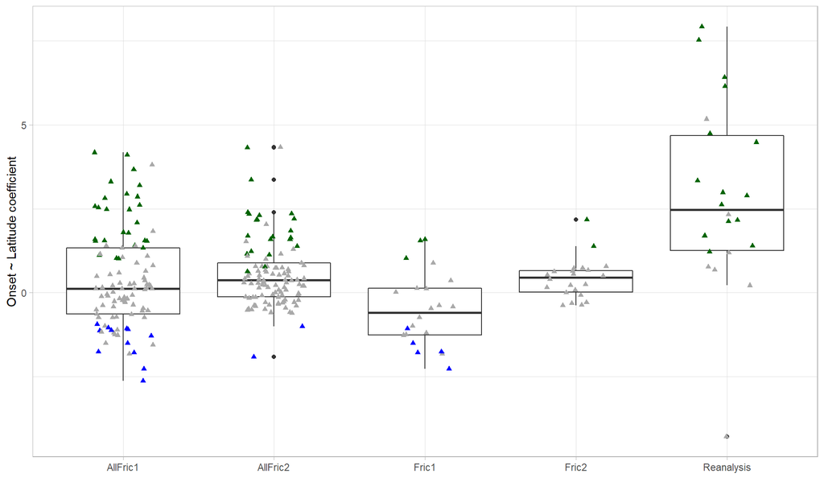

```r
##Results and visualizations

fric.results.lat<-read_excel("data/Fric_results.xlsx", sheet="models")
datasets$set<-paste(datasets$name,datasets$region,sep="-")
fric.results<-fric.results.lat %>%
  mutate(region=ifelse(region=="NA","N. America","Europe")) %>%
  mutate(reanalyzed=ifelse(paste(name,region,sep="-") %in% datasets$set,1,0))
#Model 1 = Fric Direct regression, all species
fric1<-fric.results %>%
  filter(model=="~latitude") %>%
  select(name,region,onset_coef, onset_response, term_coef, term_response) %>%
  mutate(modelnum=1)

#Model 3 = Fric Direct regression, reanalyzed species
fric3<-fric.results %>%
  filter(model=="~latitude", reanalyzed==1) %>%
  select(name,region,onset_coef, onset_response, term_coef, term_response) %>%
  mutate(modelnum=3)

#Model 2 = Fric residual regression, all species
fric2<-fric.results %>%
  filter(model=="~latitude|altitude+year") %>%
  select(name,region,onset_coef, onset_response, term_coef, term_response) %>%
  mutate(modelnum=2)

#Model 4 = Fric residual regression, reanalyzed species
fric4<-fric.results %>%
  filter(model=="~latitude|altitude+year", reanalyzed==1) %>%
  select(name,region,onset_coef, onset_response, term_coef, term_response) %>%
  mutate(modelnum=4)

#Model 5 = Reanalysis multiple regression
temp<-pivot_wider(filter(result, param=="rndLat"), id_cols =c(name, region),names_from=metric,values_from=c(param.est,param.p, response) )

result5<-temp %>%
  select(name, region, onset_coef=param.est_onset, onset_response=response_onset,term_coef=param.est_termination,term_response=response_termination) %>%
  mutate(modelnum=5)
rm(temp,fric.results.lat)

#Combine all results into 1 data frame
result.compar<-as.data.frame(rbind(fric1,fric2,fric3,fric4,result5))
result.compar$modelnum<-as.factor(result.compar$modelnum)
result.compar$s1<-1
##Create Figure 2
colorscheme<-c("blue", "darkgray", "darkgreen")
modelnames<-c("AllFric1","AllFric2","Fric1","Fric2","Reanalysis")
#Panels A, D: compare coefficients
#Panel A: Onset coefficients
onset.sp<-ggplot(data=filter(result.compar, as.numeric(modelnum)>3), aes(x=name, y=onset_coef, shape=as.factor(modelnum), fill=as.factor(onset_response))) +
  geom_point(color="black") +
  scale_shape_manual(values=c(22,21)) +
  scale_fill_manual(values=c("white","black")) +
  geom_hline(yintercept=0) +
  scale_y_continuous(breaks=seq(-8,8,2)) +
  labs(x="", y="Latitude coefficient") + coord_flip() +
  theme_light() + theme(legend.position = "none", axis.text=element_text(size=8))
#onset.sp
#Panel D: Termination coefficients
term.sp<-ggplot(data=filter(result.compar, as.numeric(modelnum)>3), aes(x=name, y=term_coef, shape=as.factor(modelnum), fill=as.factor(term_response))) +
  geom_point(color="black") +
  scale_shape_manual(values=c(22,21)) +
  scale_fill_manual(values=c("black","white","black")) +
  geom_hline(yintercept=0) +
  scale_y_continuous(breaks=seq(-8,8,2)) +
  labs(x="", y="Latitude coefficient") + coord_flip() +
  theme_light() + theme(legend.position = "none", axis.text=element_text(size=8))
#term.sp

#Panels B, E: response boxplots
#Pandel B: Onset
onset.c<-ggplot(data=result.compar, aes(x=modelnum, y=onset_coef)) +
  geom_boxplot() +
  geom_jitter(data=filter(result.compar),  aes(x=modelnum, y=onset_coef, color=as.factor(onset_response)), width=0.2, height=0, shape=17) +
  labs(x="", y="Onset ~ Latitude coefficient") +
  scale_color_manual(values=colorscheme) +
  theme_light() + theme(legend.position = "none") +
  scale_x_discrete(breaks=c(1:5),labels=modelnames)
onset.c
```

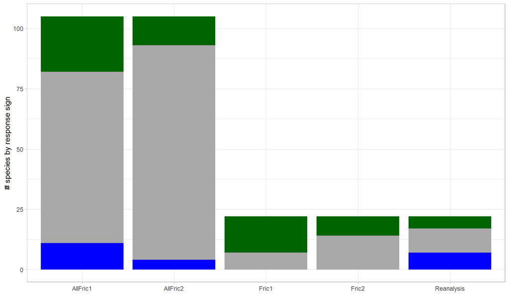

```r
#Panel D: termination
term.c<-ggplot(data=result.compar, aes(x=modelnum, y=term_coef)) +
  geom_boxplot() +
  geom_jitter(data=filter(result.compar),  aes(x=modelnum, y=term_coef, color=as.factor(term_response)), width=0.2, height=0, shape=17) +
  labs(x="", y="Termination ~ Latitude coefficient") +
  scale_color_manual(values=colorscheme) +
  theme_light() + theme(legend.position = "none") +
  scale_x_discrete(breaks=c(1:5),labels=modelnames)

#Panels C, F: stacked barplots
#Panel c: Onset responses
onset.st<-ggplot(data=result.compar, aes(x=modelnum, y=s1, fill=as.factor(onset_response))) +
  geom_bar(position=position_stack(reverse=T), stat="identity")  +
  scale_fill_manual(values=colorscheme) +
  labs(x="", y="# species by response sign") + theme_light() + theme(legend.position = "none") +
  scale_x_discrete(breaks=c(1:5),labels=modelnames)
#Panel F: Termination responses
term.st<-ggplot(data=result.compar, aes(x=modelnum, y=s1, fill=as.factor(term_response))) +
  geom_bar(position=position_stack(reverse=T), stat="identity") +
  scale_fill_manual(values=colorscheme) +
  theme_light() +
  labs(x="", y="# species by response sign")+ theme(legend.position = "none")+
  scale_x_discrete(breaks=c(1:5),labels=modelnames)
term.st
```

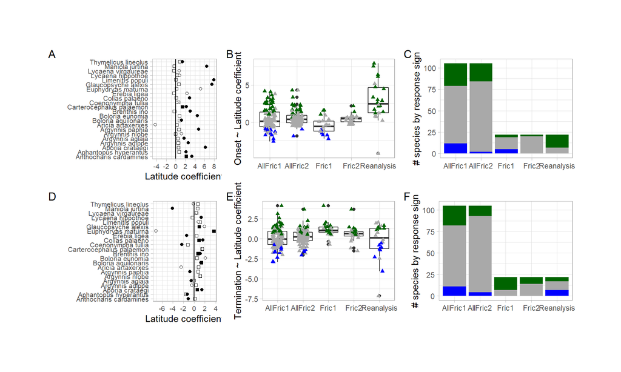

```r
##Combine panels into Figure 2:
p1<-onset.sp+labs(tag="A")
p2<-onset.c+labs(tag="B")
p3<-onset.st+labs(tag="C")
p4<-term.sp+labs(tag="D")
p5<-term.c+labs(tag="E")
p6<-term.st+labs(tag="F")

#pdf_filename<-("output/LarsenShirey2020_Fig2.pdf")
fig2<-grid.arrange(ncol=3, grobs=list(p1, p2, p3, p4, p5, p6), top="\n\n", bottom="\n\n", left="\n\n", right="\n\n", width=10, height=5)
```

```r
#ggsave(pdf_filename, arrangeGrob(fig2, nrow=1), width=10, height=5, scale=1.5, dpi=600,units="in")
fig2
```

## Create results table (Supplemental Table 2)

```r
fric.table<-fric.results %>%
  filter(reanalyzed==1) %>%
  select(name, region, model, onset_response, onset_p, onset_coef, term_response, term_p=term_p_mean, term_coef)

fric.onset<-fric.table %>%
  select(name:model, Fric_singleRegression_sign=onset_response, Fric_singleRegression_p=onset_p,Fric_singleRegression_coef=onset_coef,) %>%
  mutate(phenometric="onset")
fric.term<-fric.table %>%
  select(name:model, Fric_singleRegression_sign=term_response, Fric_singleRegression_p=term_p,Fric_singleRegression_coef=term_coef,) %>%
  mutate(phenometric="termination")
fric.table<-rbind(fric.onset, fric.term)
fric.table<-fric.table %>%
  mutate(indep.variable=ifelse(model=="~latitude","latitude",ifelse(model=="~year","year",0)) )

fric1<-filter(fric.table,indep.variable %in% c("latitude","year"))
fric2<-fric.table %>%
  filter(!indep.variable %in% c("latitude","year")) %>%
  select(name, region,phenometricFric_resid.regress_sign=Fric_singleRegression_sign, Fric_resid.regress_p=Fric_singleRegression_p,Fric_resid.regress_coef=Fric_singleRegression_coef) %>%
  mutate(indep.variable="latitude")

reanalysis.table<-result %>%
  select(name, region, phenometric=metric, param, response, param.p, param.est) %>%
  mutate(indep.variable=ifelse(param=="year","year","latitude"))%>%
  select(name, region, phenometric, indep.variable, Reanalysis_sign=response, Reanalysis_p=param.p, Reanalysis_coef=param.est)

supptable2<-merge(reanalysis.table,fric1[,c(1,2,4:8)], by=intersect(names(reanalysis.table),names(fric1[,c(1,2,4:8)])))

supptable2<-merge(supptable2,fric2,by=intersect(names(supptable2),names(fric2)), all.x=T)
summary(supptable2)
```

```
##      name              region          indep.variable     phenometric
##  Length:132         Length:132         Length:132         Length:132
##  Class :character   Class :character   Class :character   Class :character
##  Mode  :character   Mode  :character   Mode  :character   Mode  :character
##
##
##
##
##  Reanalysis_sign   Reanalysis_p      Reanalysis_coef
##  Min.   :-1.000   Min.   :0.000000   Min.   :-7.1347
##  1st Qu.: 0.000   1st Qu.:0.002791   1st Qu.:-0.1524
##  Median : 0.000   Median :0.048235   Median : 0.3878
##  Mean   : 0.197   Mean   :0.201471   Mean   : 0.8863
##  3rd Qu.: 1.000   3rd Qu.:0.297854   3rd Qu.: 1.7543
##  Max.   : 1.000   Max.   :0.960316   Max.   : 7.9281
##
##  Fric_singleRegression_sign Fric_singleRegression_p Fric_singleRegression_coef
##  Min.   :-1.0000            Min.   :0.0000006       Min.   :-2.2694
##  1st Qu.: 0.0000            1st Qu.:0.0150962       1st Qu.:-0.4220
##  Median : 0.0000            Median :0.1161413       Median : 0.1393
##  Mean   : 0.2121            Mean   :0.2672617       Mean   : 0.2179
##  3rd Qu.: 1.0000            3rd Qu.:0.4861903       3rd Qu.: 0.9719
##  Max.   : 1.0000            Max.   :0.9870071       Max.   : 4.1062
##
##  phenometricFric_resid.regress_sign Fric_resid.regress_p
##  Min.   :0.0000                     Min.   :0.00013
##  1st Qu.:0.0000                     1st Qu.:0.06726
##  Median :0.0000                     Median :0.31329
##  Mean   :0.2273                     Mean   :0.36292
##  3rd Qu.:0.0000                     3rd Qu.:0.62514
##  Max.   :1.0000                     Max.   :0.99961
##  NA's   :44                         NA's   :44
##  Fric_resid.regress_coef
##  Min.   :-1.5254
##  1st Qu.: 0.1255
##  Median : 0.5358
##  Mean   : 0.5027
##  3rd Qu.: 0.7490
##  Max.   : 3.6603
##  NA's   :44
```

```r
##This partial supplementary table 2 does not include the residual regression year results
#write.csv(supptable2,file="output/supp_table2_part.csv")
```

#####A small break between creating the panels and assmembling Supplemental Figure 1. The chunk below combines the panels into Supplemental Figure 1.

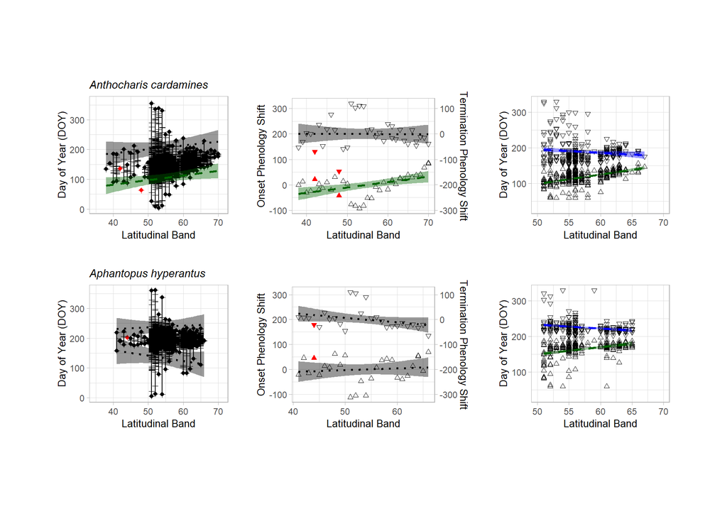

```r
#### COMBINE ALL PANELS INTO SUPPLEMENTAL FIGURE 1
(p1<-grid.arrange(sup1a[[1]],sup1b[[1]],sup1c[[1]],sup1a[[2]],sup1b[[2]],sup1c[[2]],nrow = 2))
```

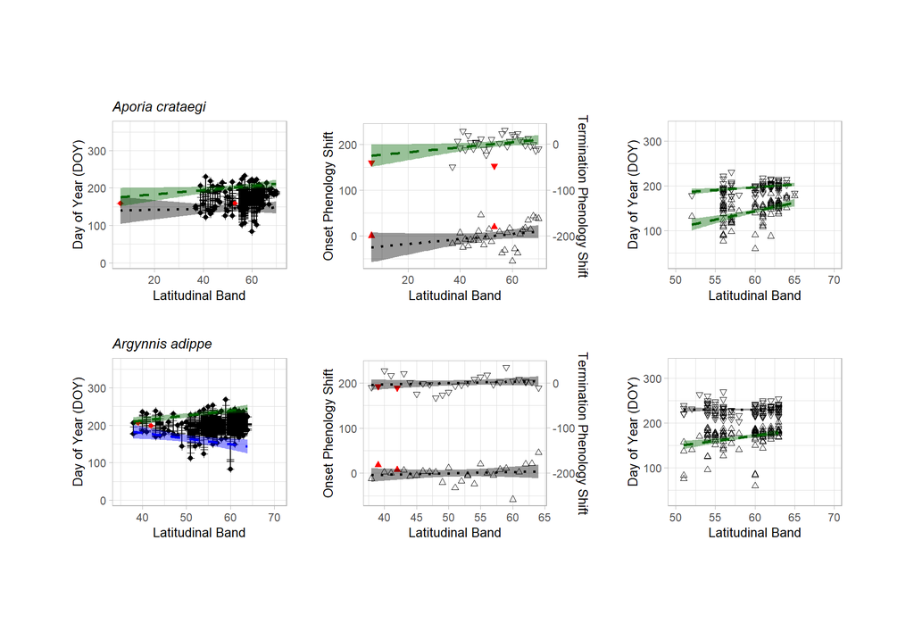

```r
(p2<-grid.arrange(sup1a[[3]],sup1b[[3]],sup1c[[3]],sup1a[[4]],sup1b[[4]],sup1c[[4]],nrow = 2))
```

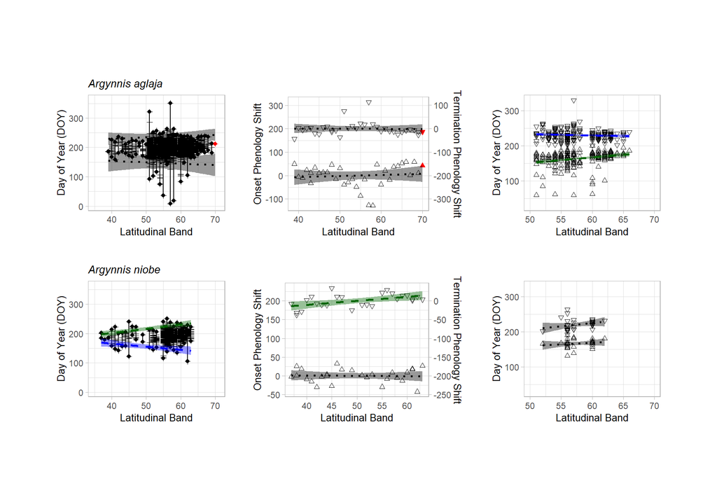

```r
(p3<-grid.arrange(sup1a[[5]],sup1b[[5]],sup1c[[5]],sup1a[[6]],sup1b[[6]],sup1c[[6]],nrow = 2))
```

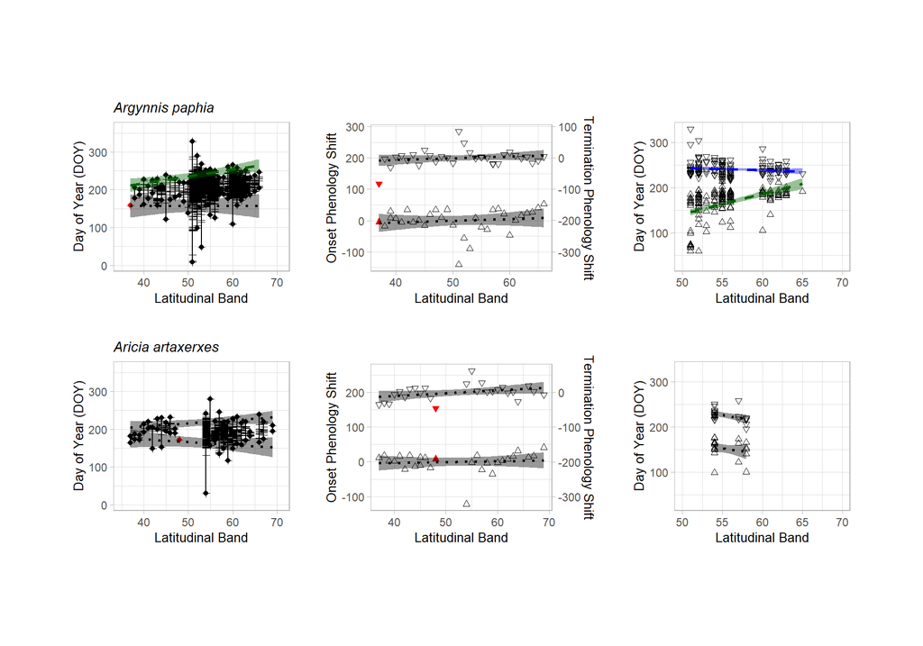

```r
(p4<-grid.arrange(sup1a[[7]],sup1b[[7]],sup1c[[7]],sup1a[[8]],sup1b[[8]],sup1c[[8]],nrow = 2))
```

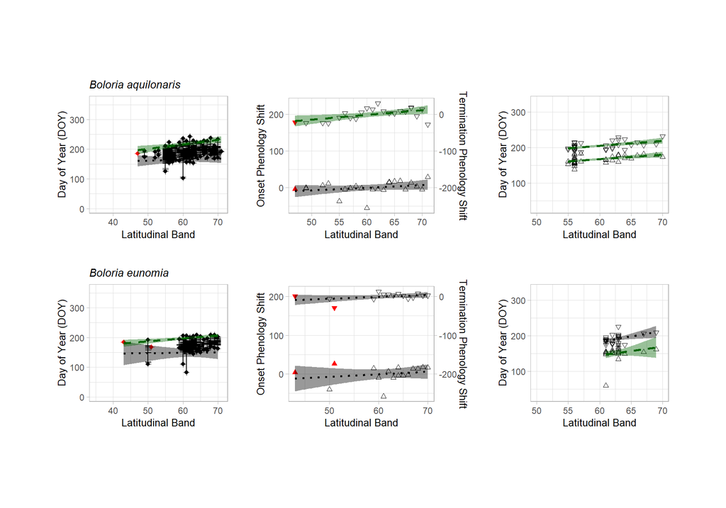

```r
(p5<-grid.arrange(sup1a[[9]],sup1b[[9]],sup1c[[9]],sup1a[[10]],sup1b[[10]],sup1c[[10]],nrow = 2))
```

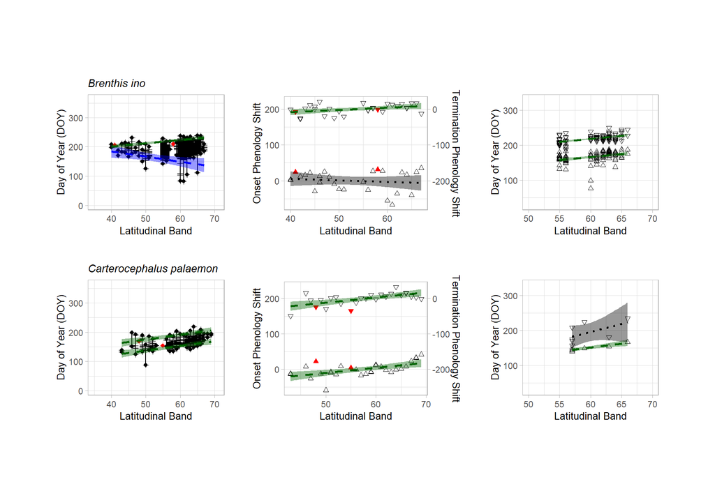

```r
(p6<-grid.arrange(sup1a[[11]],sup1b[[11]],sup1c[[11]],sup1a[[12]],sup1b[[12]],sup1c[[12]],nrow = 2))
```

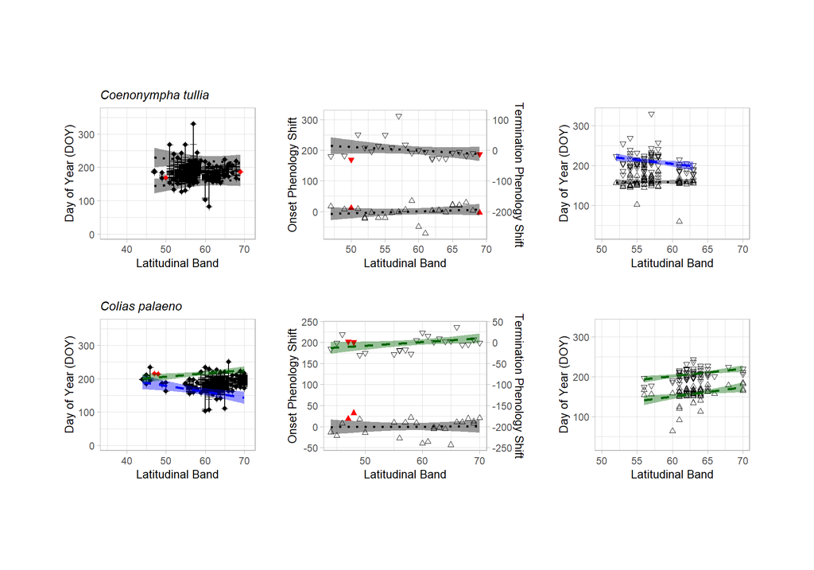

```r
(p7<-grid.arrange(sup1a[[13]],sup1b[[13]],sup1c[[13]],sup1a[[14]],sup1b[[14]],sup1c[[14]],nrow = 2))
```

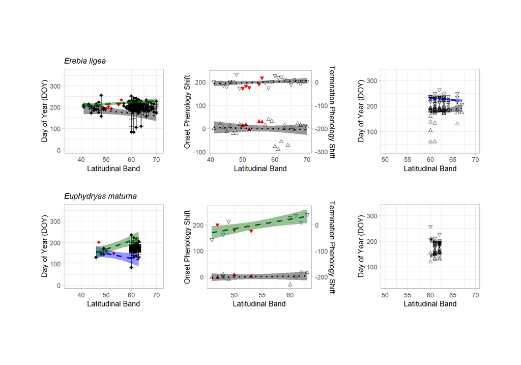

```r
(p8<-grid.arrange(sup1a[[15]],sup1b[[15]],sup1c[[15]],sup1a[[16]],sup1b[[16]],sup1c[[16]],nrow = 2))
```

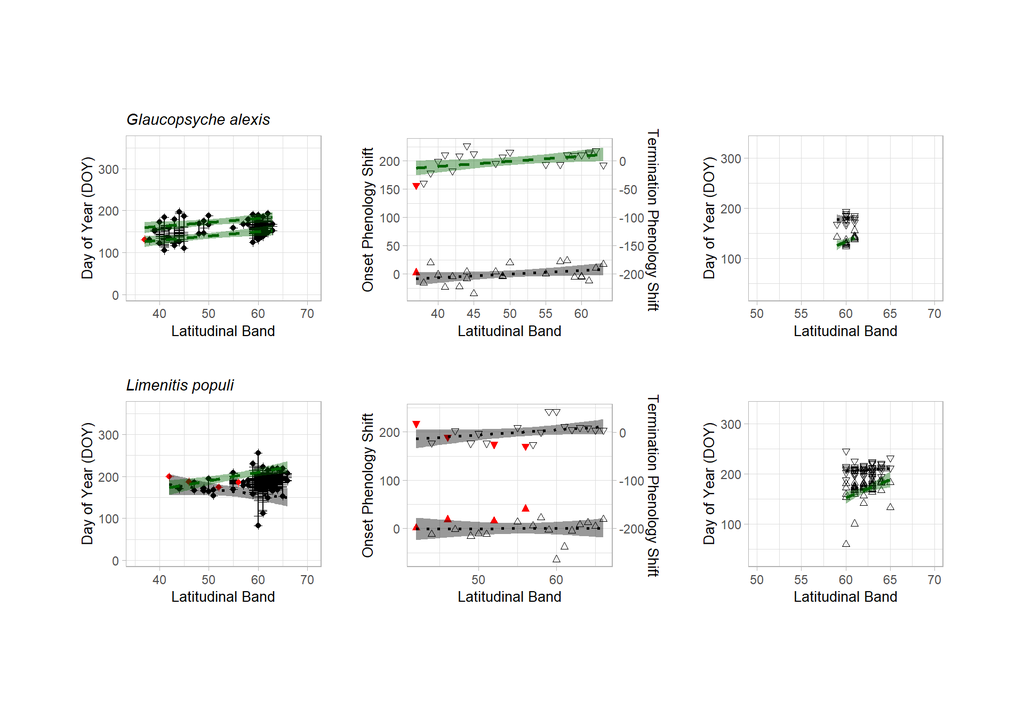

```r
(p9<-grid.arrange(sup1a[[17]],sup1b[[17]],sup1c[[17]],sup1a[[18]],sup1b[[18]],sup1c[[18]],nrow = 2))
```

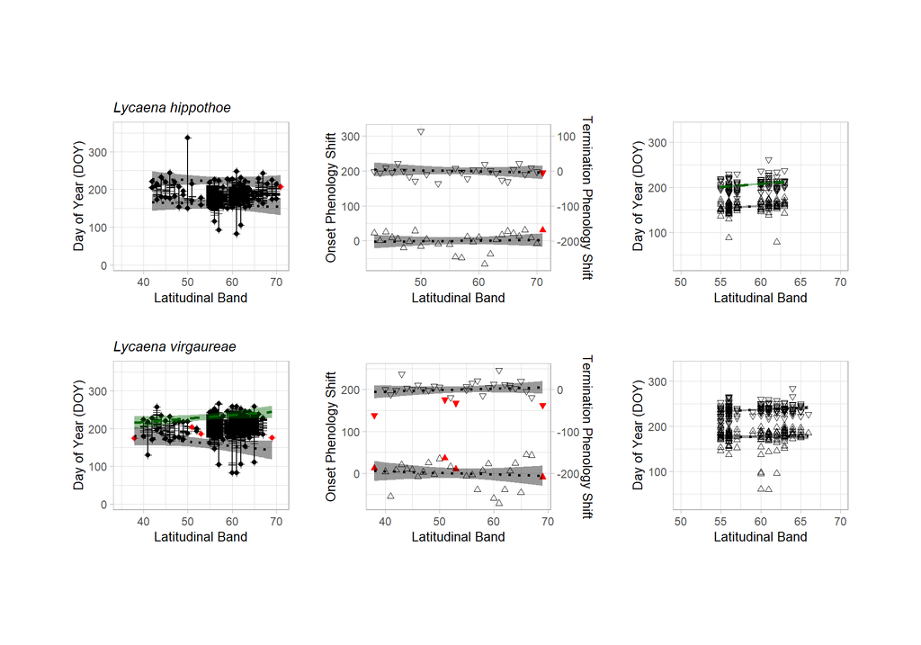

```r
(p10<-grid.arrange(sup1a[[19]],sup1b[[19]],sup1c[[19]],sup1a[[20]],sup1b[[20]],sup1c[[20]],nrow = 2))
```

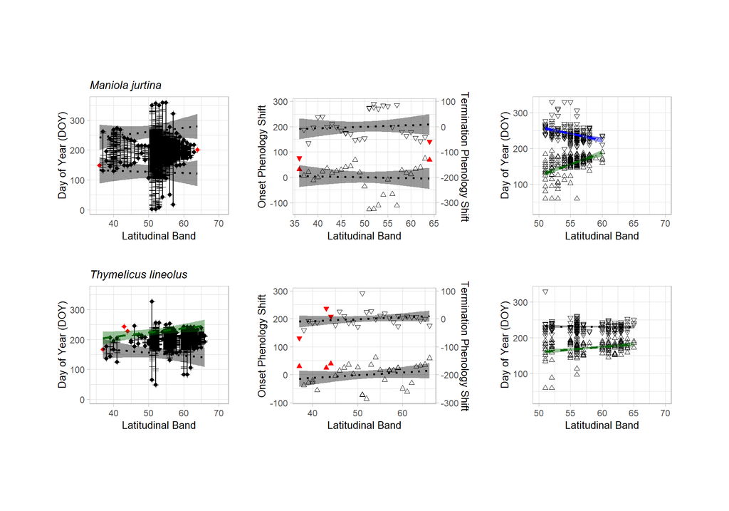

```r
(p11<-grid.arrange(sup1a[[21]],sup1b[[21]],sup1c[[21]],sup1a[[22]],sup1b[[22]],sup1c[[22]],nrow = 2))
```

```r
##### END SUP FIG 1
```

This is the end of this analysis.